# Pharmacokinetic Parameter Estimations using ‘`R`’

[figure not shown]

# 1 Introduction

In the self-directed learning session last week, we recapped the some of the skills gained in Year 1 around quantitative pharmacology using ‘`R`’.

This workshop is split into two parts. Part 1 is designed to be completed today. Part 2 is designed to be completed in a couple of weeks time at your next quantitative session (or in your own time if you prefer).

In Part 1 workshop, we will build on your learning and coding to date. We will also explore the concept of central tendency and what measures of central tendency might be useful in pharmacokinetic analysis.

In part 2, we will learn how to estimate bioavailability and we will recap the concept of bioequivalence and use `R` to perform simple calculations to assess bioequivalence.

## 1.1 Learning outcomes

Part 1

- Recap use of `R` and `ggplot2` to plot pharmacokinetic data and estimate some pharmacokinetic parameters
- Save plots made using `ggplot2`
- Estimate Cmax and $AUC_{0-t}$
- Understand the difference between arithmetic and geometric means
- Know when to use the arithemtic mean, median and geometric mean in pharmacokinetic analysis
- Know how variability of pharmacokinetic data is presented (% geometric coefficient of variation)
- Describe (quantitatively) how a drug with high inter-individual variability is identified in pharmacokinetic analysis

Part 2

- Explain how to calculate bioavailability from pharmacokinetic data
- Calculate bioavailability from some data in `R`
- Explain how to calculate bioequivalence from pharmacokinetic data
- Calculate bioequivalence from some data in `R`
- Understand the concept of $AUC_{0-\infty}$

## 1.2 Further learning

- Use ‘`R`’ to produce a plot of concentration-time data displaying mean and error bars (e.g. for 95% confidence interval or standard error)
- Understand the FDA and EMA requirements for proving bioequivalence above the basic calculation we have performed
- Calculate $AUC_{0-\infty}$
- Advanced calculations required as evidence of bioequivalence for FDA/EMA approval

This page is designed to provide you with notes of the session and be a handy resource when you come to revision. There are examples of code and the corresponding output from `R` as we go along.

## 1.3 Accessing `RStudio` on a University computer

Remember, when you are using a University computer, you need to access `RStudio` via the University servers. The link for this is [here](https://stats4.sgul.ac.uk/rstudio). I’d suggest saving this as a “favourite” for future access.

### 1.3.1 Setting the working directory

A reminder to set your working directory to the folder that your data is in using the `setwd()` function. The *easiest* way to do this is to click ‘session’ then ‘set working directory’. You can also do it with code of course…..(you can do everything with code!)

```r
setwd("INSERT YOUR FILE PATH HERE")
# or if on the server:
setwd("~/intro_pk/intro_R/")
getwd() # check the working directory
list.files() # view the files available in your working directory
```

## 1.4 Packages for this session

You *will* need to run the following code in order to utilise the correct pacakges.

```r
.libPaths( c( .libPaths(),
              "/homes/dlonsdale-pharmacokinetics/sghms/bms/shares/Advanced-Pharmacokinetics/4.4.2/library") )
#note that you need the '.' before 'libPaths'
library(tidyverse)
```

# 2 Part 1

## 2.1 Data

Dataset_A contains the PK data for IV administration of Drug X Dataset_B contains the PK data for oral administration of Drug X

We will use these datasets for part 1 of this session. You can download the data for this session directly from GitHub. There are two files. Copy and paste my code.

```r
dataset_A <- read.csv("https://raw.githubusercontent.com/dlonsdal/SGUL_PK_data/refs/heads/main/pk2_param_estimate/dataset_A.csv")
dataset_B <- read.csv("https://raw.githubusercontent.com/dlonsdal/SGUL_PK_data/refs/heads/main/pk2_param_estimate/dataset_B.csv")
```

## 2.2 Plotting the data and saving your plot

### 2.2.1 Task: plot the IV data and save your plot

- use the `ggplot2` package to plot the data for the IV data
- group by ID using colour or symbols
- label the x-axis and the y-axis with units (concentration is in mg/L; time is in hours)
- add a title to each plot
- use ggsave(“FILENAME.JPEG”) or ggsave(“FILENAME.PDF”) to save the plot to a jpeg or pdf file in your working directory folder
- try to adjust the width and height of your saved plot.

I am going to give you the solutions for this part of the task to help refresh folks memory.

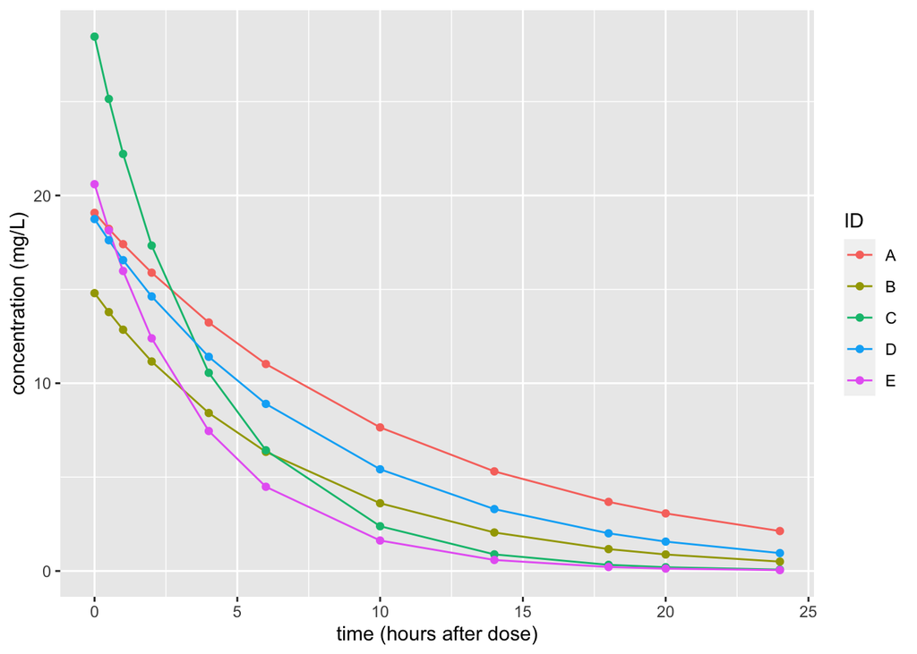

Figure 1: Concentration-time curve for Drug X given intravenously

```r
ggplot(data=dataset_A, aes(x=time, y=conc, col=ID))+ #the 'col=ID' ensures we give separate colour and line for each individual
  geom_line()+ # plots a line
  geom_point()+ # plots the observations as datapoints
  xlab("time (hours after dose)")+ # adds x axis label
  ylab("concentration (mg/L)")
```

```r
# save as JPEG specifying width
ggsave("IV_data_small.jpeg", width=2) #note that standard units are 'inches' in R
ggsave("IV_data_large.jpeg", width= 12)

# go to your working directory and look at these two files. Is one more useful than the other?

# saving as as PDF is a scalable vector format and therefore more useful
# a vector graphic can be resized, reshaped or rescaled without losing image quality
ggsave("IV_data.PDF")
```

### 2.2.2 Task: plot the oral data and save your plot

Repeat the task above for the oral dataset. I am not going to give you the answers for this!

## 2.3 Estimating pharmacokinetic parameters

### 2.3.1 Task: Esimate $C_{max}$

- Estimate the $C_{max}$ for each participant for the IV and the oral data
- Estimate the mean $C_{max}$ for the IV data and the oral data

**Reminder about piping**

Piping is a tool that allows us to undertake multiple logical steps to achieve a desired output in our text using “`%>%`” between steps. Technically, `%>%` is found in the `magrittr()` package, but when you load `tidyverse()` , `magrittr()` is automatically loaded.

I am going to give you the code for the IV dataset. See if you can edit this to give a value for the oral dataset.

```r
# remember to load the tidyverse package if you have not already
library(tidyverse)
# below, we tell R to take 'dataset_A' (the IV data), group by 'ID' then give the cmax
dataset_A%>%
  group_by(ID)%>%
  summarise(cmax=max(conc))
```

```
## # A tibble: 5 × 2
##   ID     cmax
##   <chr> <dbl>
## 1 A      19.1
## 2 B      14.8
## 3 C      28.5
## 4 D      18.7
## 5 E      20.6
```

```r
# here we tell R to take 'dataset_A', and give the Cmax for each ID
# and then summarise the mean of these values - thus the output is the mean cmax
dataset_A%>%
  group_by(ID)%>%
  summarise(cmax=max(conc)) %>%
  ungroup() %>%
  summarise(mean(cmax))
```

```
## # A tibble: 1 × 1
##   `mean(cmax)`
##          <dbl>
## 1         20.3
```

### 2.3.2 Task: Estimate $AUC_{0-24}$

- Estimate the $AUC_{0-24}$ for each participant for the IV and the oral data
- Estimate the mean $AUC_{0-24}$ for the IV data and the oral data

Again, I will give you a solution for the IV data.

```r
library(DescTools)
# loading this allows us to use the trapezoid function

# here we tell R to take 'dataset_A', group by 'ID' then calculate the AUC
dataset_A%>%
  group_by(ID) %>%
  summarise(AUC=AUC(time,conc,method='trapezoid'))
```

```
## # A tibble: 5 × 2
##   ID      AUC
##   <chr> <dbl>
## 1 A     187.
## 2 B     103.
## 3 C     118.
## 4 D     145.
## 5 E      83.1
```

```r
# here we tell R to take 'dataset_A', and calculate the AUC for each ID
# and then summarise the mean of these values - thus the output is the mean AUC
dataset_A %>%
  group_by(ID) %>%
  summarise(AUC=AUC(time,conc,method='trapezoid')) %>%
  ungroup()  %>%
  summarise(mAUC=
              mean(AUC))
```

```
## # A tibble: 1 × 1
##    mAUC
##   <dbl>
## 1  127.
```

## 2.4 Arithimetic and Geometric mean

### 2.4.1 Arithmetic mean

With the code we have used in the course so far, we are calculating the arithmetic mean. The arithmetic mean is often colloquially referred to as “*the* mean” or “*the* average”. It is frequently the only type of “mean” that people are aware of. It is a useful tool for summarising a set of data into one value, somewhere in the middle (the central tendency). It is a fairly intuitive calculation that we often don’t really take much time thinking about. It incorporates all data points. When looking at a large sample from a normally distributed population, the sample mean ($\bar{x}$) is considered an unbiased estimator of the population mean ($\mu$).

The formula for the arithmetic mean ($\mu$) is
$$\mu = \frac{\sum_{i=1}^{N} x_i}{N}$$

Where:

- $x_i$ are the data points of each individual
- $N$ is the number of data points in the whole population
- $i$ can therefore take a value from $1$ to $N$ ($x_1$ is the value from the first individual, $x_2$ from the second etc)

The formula for arithmetic mean from a sample is often given a different symbol ($\bar{x}$). The equation is the same:

$$\bar{x} = \frac{\sum_{i=1}^{n} x_i}{n}$$

Where:

- $\bar{x}$ is the sample mean.
- $x_i$ are the individual observations in the sample.
- $n$ is the sample size (the number of observations in the sample)

For example, if we have the set of numbers $\{5, 8, 11, 15, 21\}$, the arithmetic mean is calculated as:

$$\bar{x} = \frac{5 + 8 + 11 + 15 + 21}{5} = \frac{60}{5} = 12$$
However, the mean is not always the preferred measure of central tendency. Its most significant limitation is its sensitivity to extreme values (outliers) and/or data that is skewed/asymetrical in distribution. For example if we replace $21$ with $100$ in the above set, the mean is heavily influenced by the $100$ outlier.

$$\bar{x} = \frac{5 + 8 + 11 + 15 + 100}{5} = \frac{139}{5} = 27.8$$
In this scenario you might choose to use the median to estimate the central tendency of these data
$$\text{median}=11$$
Let’s look at an example with some pharmacokinetic data.

### 2.4.2 Arithmetic mean is a poor estimate of central tendency in skewed data

In Figure 2, amoxicillin clearance from 10000 patients is plotted. You can see that the data is right skewed. From what we know about the pharmacological principles behind pharmacokinetic parameters, this should be intuitive - you cannot have a negative clearance and so the plot will naturally have some grouping around low clearance values and a long tail toward higher clearance values to the right.

The plot shows how this right skew pulls the arithmetic mean to the right. Relying on this figure to describe pharmacokinetic data will give a falsely high impression of the population value of clearance.

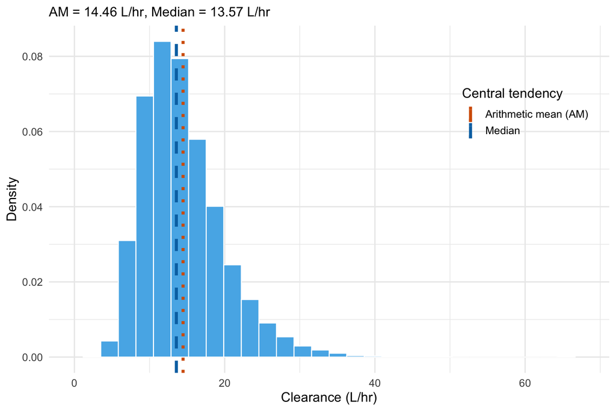

Figure 2: Distribution of simulated amoxicillin clearance (CL), illustrating the right-skew typical of pharmacokinetic parameters and the divergence between the arithmetic mean (AM) and median.

#### 2.4.2.1 So I should just use median, right?

You *could* just use sample median. This value is well recognised and understood. It does have limitations however. For example, as a non-parametric statistic it is less straightforward to use to make inferences from the data - we cannot easily undertake a t-test or derive confidence intervals for a population median. We are also not usually *just* interested in the central tendency. We are also interested in variability between individuals and this is less easily described when using median.

### 2.4.3 Geometric mean

Statisticians *love* to be able to generalise. It allows them to use a set of standard calculations and apply them to different data sets that share similar properties.

For example, if you look at a plot of amoxicillin clearance next to a plot of amoxicillin volume of distribution (top panels Figure 3), you can see that although they are *different* pharmacokinetic parameters, the shape of the plots (the distribution) is *similar*. These parameters are often (*approximately*) ‘log-normally’ distributed. This means that if you take the logarithm of the data, the distribution is transformed to a ‘normal’ distribution. This is shown in bottom panels of the plot. You can see that the median and arithmetic mean of the log transformed data converge.

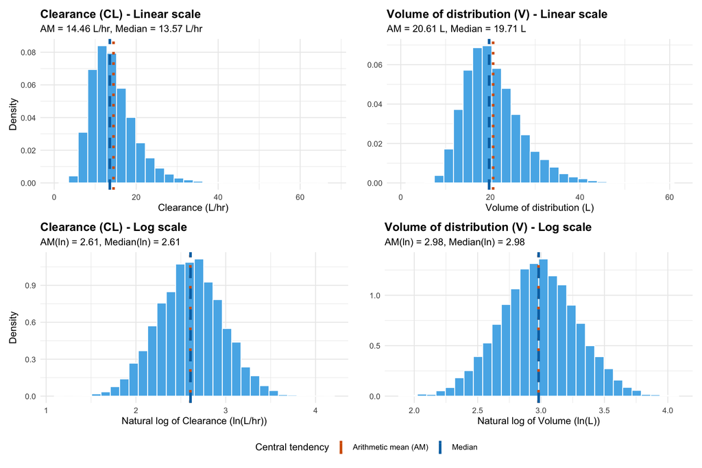

Figure 3: Figure 1: Comparison of amoxicillin pharmacokinetic parameters (CL and V) on the linear and log-transformed scales. The linear scale shows a right-skewed (log-normal) distribution, causing the arithmetic mean (AM) and median to diverge. The log-transformed scale demonstrates a symmetrical (normal) distribution, where the arithmetic mean (equivalent to the geometric mean on the linear scale) and median converge.

The fact that the arithmetic mean after undergoing log-transformation *is* a useful measure of central tendency of the log-transformed data is useful to us! You can transform this result back into the standard domain. This measure of central tendency is then known as the *geometric mean* of the data. The equation to calculate the geometric mean is
$$\text{GM} = \exp\left( \frac{1}{n} \sum_{i=1}^{n} \ln(x_i) \right)$$

Where:

- $x_i$ is the $i$-th observed value in the dataset.
- $n$ is the total number of observations (the sample size).
- $\ln(x_i)$ is the natural logarithm of the observation.
- $\sum_{i=1}^{n}$ is the summation notation.
- $\exp(\dots)$ is the exponential function (anti-logarithm).

If you hate using log transformations, it can also be calculated as follows:

$$\text{GM} = \left( \prod_{i=1}^{n} x_i \right)^{1/n}$$

Where:

- $x_i$ is the $i$-th observed value in the dataset.
- $n$ is the total number of observations (the sample size).
- $\prod_{i=1}^{n} x_i$ is the product of all $x_i$ values ($x_1 \times x_2 \times x_3 \cdot \dots \times x_n$).

Figure 4 shows median, geometric and arithmetic means displayed.

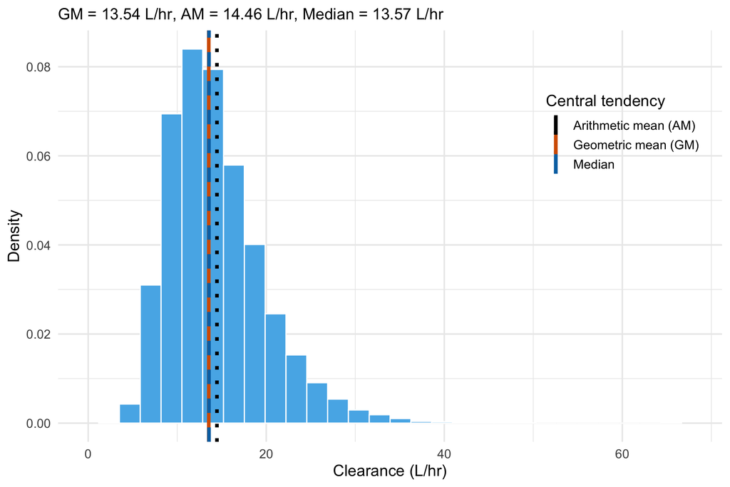

Figure 4: Figure 1: Distribution of simulated amoxicillin clearance (CL), illustrating the right-skew typical of pharmacokinetic parameters and the central measures of geometric mean (GM), arithmetic mean (AM), and median.

#### 2.4.3.1 Exemplar with our small skewed dataset

If we go back to our small skewed dataset sample {5, 8, 11, 15, 100}. The Geometric mean is calculated as follows:
$$\text{GM} = \exp\left(\frac{\ln(5) + \ln(8) + \ln(11) + \ln(15) + \ln(100)}{5}\right)\approx 14.59$$
Table 1 compares arithmetic mean, geometric mean and median from this dataset.

Table 1: Comparison of Central Tendency Measures for Data Set {5, 8, 11, 15, 100}

| Statistic | Formula / Calculation | Result | Interpretation |
| --- | --- | --- | --- |
| Arithmetic Mean ($\bar{x}$) | $\frac{\sum x_i}{n}$ | $\frac{139}{5} = 27.8$ | Heavily influenced by the outlier, $\mathbf{100}$. |
| Median | The middle value when sorted | $5, 8, \mathbf{11}, 15, 100$ | Robustly estimates the center, ignoring the magnitude of the outlier. |
| Geometric Mean (GM) | $\exp\left(\frac{\sum \ln(x_i)}{n}\right)$ | $\exp\left(\frac{13.4}{5}\right) \approx \exp(2.68) \approx 14.59$ | Less influenced than the arithmetic mean, reflecting the central tendency of the ratios. |

### 2.4.4 Describing variability in log-normally distributed data

#### 2.4.4.1 Sample (arithmetic) standard deviation

You will be used to describing variability associated with arithmetic mean. This is useful because it provides some description of the spread of the data, alongside its central tendency. Typically the statistic you will have used is the standard deviation. You will often see sample mean and sample standard deviation used as estimates for population values. For example, the mean weight from a sample of schoolchildren alongside sample standard deviation provides an estimate for the population mean and population standard deviation of *all* school children. Sample standard deviation is calculated as follows:
$$s = \sqrt{\frac{\sum_{i=1}^{n} (x_i - \bar{x})^2}{n-1}}$$

Where:

- $s$ is the **sample standard deviation** (often labelled $\text{SD}$).
- $x_i$ is the $i$-th observed value in the sample.
- $\bar{x}$ is the **arithmetic mean** of the sample.
- $n$ is the **sample size**.
- $n-1$ is the **degrees of freedom**, used to ensure $s$ is an unbiased estimate of the population standard deviation

It is important to note that arithmetic standard deviation is symmetrical around the mean. Values are often reported with a +/- e.g.Mean weight $60 \text{ kg} \pm 2 \text{ kg} \ (\text{SD})$. You would expect the same number of people to have a weight of 62 kg as you would for 58 kg.

#### 2.4.4.2 Geometric standard deviation and coefficient of variation (%CV)

The problem with log-normally distributed data is that a ‘standard’ arithmetic standard deviation will often over-estimate the spread of data *and*, as the data is not symmetrical, will contain different amounts of data on either side of the mean.

The solution is back in the log-domain. If we log-transform the data we have normally distributed data again and so can calculate our usual variability measure.
$$s_{\ln} = \sqrt{\frac{\sum_{i=1}^{n} (\ln(x_i) - \overline{\ln(x)})^2}{n-1}}$$

Where:

- $s_{\ln}$ is the **sample standard deviation of the log transformed data**.
- $\ln(x_i)$ is the **natural logarithm** of the $i$-th observed value.
- $\overline{\ln(x)}$ is the **arithmetic mean of the log-transformed data**.
- $n$ is the **sample size**.
- $n-1$ are the **degrees of freedom** (the unbiased denominator for sample variance).

Then, a bit like with the geometric mean, we can calculate our geometric standard deviation by converting back into the standard domain
$$\text{GSD} = \exp(s_{\ln})$$

Where:

- $\text{GSD}$ is the **Geometric Sample Standard Deviation**.
- $\exp(\dots)$ is the **exponential function** (or anti-logarithm, $e^{(\dots)}$).
- $s_{\ln}$ is the **sample standard deviation of the natural logarithm of the data**

Finally, because geometric standard deviation is not all that intuitive a number (and it can’t be expressed as a $\pm$). Variability in pharmacokinetic data is often presented as a percentage geometric coefficient of variability (often shortened to $%CV%$). This is calcluated as follows:

$$\%\text{GCV} = \sqrt{\exp(s_{\ln}^2) - 1} \times 100$$

Where:

- $\%\text{GCV}$ is the **Geometric Coefficient of Variation** (expressed as a percentage).
- $\exp(\dots)$ is the **exponential function** (or anti-logarithm).
- $s_{\ln}^2$ is the **sample variance of the natural log transformed data** (the square of $s_{\ln}$, calculated using the $n-1$ denominator)

## 2.5 tl;dr;tmm

(too long; didn’t read; too much maths)

I appreciate that for some that will have been too much mathematics. To preempt the obvious question - no, I do not expect you to know and regurgitate the above calculations in an exam. The detail is provided to aid your understanding. Here is a bare bones summary:

*Many* pharmacokinetic parameters are *not* normally distributed. You should *not* use standard descriptive statistics like sample arithmetic mean and sample arithmetic standard deviation as estimates for true population values in these cases.

Instead we can use geometric mean and geometric coefficient of variation. These statistics are useful for right skewed (log-normally distributed) data. The tables provide some calculations and the formula. Note that statistical software can often do these calculations for you. You just need to know when to apply them.

Table 2: Comparison of Arithmetic and Geometric Central Tendency Measures

| Measure | Central Tendency | Formula for Central Tendency | Appropriate for |
| --- | --- | --- | --- |
| Arithmetic | Arithmetic Mean ($\bar{x}$ or $\text{AM}$) | $$\bar{x} = \frac{1}{n} \sum_{i=1}^{n} x_i$$ | $\text{Normal}$ (Symmetrical) Data |
| Geometric | Geometric Mean ($\text{GM}$) | $$\text{GM} = \exp\left( \frac{1}{n} \sum_{i=1}^{n} \ln(x_i) \right)$$ | $\text{Log-Normal}$ (Skewed) Data |

Table 3: Comparison of Arithmetic and Geometric Variability Measures

| domain | statistical parameter | formula | interpretation |
| --- | --- | --- | --- |
| **arithmetic measures** |  |  |  |
| arithmetic | standard deviation (SD) | $$\mathbf{s} = \sqrt{}\left[\tfrac{1}{n-1} \sum_{i=1}^{n} (x_i - \bar{x})^2\right]$$ | absolute measure of spread. the $68\%$ range is $\text{AM} \pm 1 \cdot \text{SD}$ (additive). |
| arithmetic | coefficient of variation (%CV) | $$\%\text{CV} = \left( \frac{s}{\bar{x}} \right) \times 100$$ | relative measure of spread around the AM. used for normally distributed data. |
| **geometric measures** |  |  |  |
| geometric | geometric standard deviation (GSD) | $$\text{GSD} = \exp(s_{\ln})$$ | the multiplicative factor of spread. the $68\%$ range is $\text{GM}/\text{GSD}$ to $\text{GM} \times \text{GSD}$ (multiplicative). |
| geometric | geometric coefficient of variation (%GCV) | $$\%\text{GCV} = \sqrt{\exp(s_{\ln}^2) - 1} \times 100$$ | relative symmetrical scatter around the geometric mean (GM). preferred for log-normal data. |

Note: AM = arithmetic mean; $\mathbf{s}$ = sample standard deviation; $\bar{x}$ = arithmetic mean; %CV = percent coefficient of variation; GM = geometric mean; GSD = geometric standard deviation; $s_{\ln}$ = sample standard deviation of natural log-transformed data; $s_{\ln}^2$ = sample variance of natural log-transformed data; %GCV = percent geometric coefficient of variation. Note: $\pm 1 \cdot \text{SD}$ typically encompasses approximately $68\%$ of data points in a normal distribution.

### 2.5.1 Is there a definition of a ‘high’ amount of variability in pharmacokinetics?

Yes. The FDA considers a %GCV of 30% or higher in $C_{max}$ or $AUC_{0-\infty}$ to represent high inter-individual variability. This means that the drug exposure is considered to be highly variable between individuals.

### 2.5.2 OK so it is geometric for all……!

Erm. No. Sorry. Somewhat irritatingly you cannot use this principle for all of the pharmacokinetic parameters.

Here is an example:

$T_{max}$, the time to maximum concentration is *highly* dependent upon the sampling schedule and can *only* take the discrete values of the times samples were taken. For example, if you *only* take samples at 0.25, 0.5, 1 and 1.25 hours then $T_{max}$ can only be one of these. So for $T_{max}$ we report median and range (min-max). Sorry.

Table 4: Preferred summary statistics for key pharmacokinetic parameters (FDA)

| PK Parameter | Underlying Distribution | Preferred Central Tendency | Preferred Variability Measure |
| --- | --- | --- | --- |
| Area Under the Curve (AUC) | Log-Normal (Skewed) | $\text{Geometric Mean (GM)}$ | $\text{Geometric CV (%GCV)}$ |
| Maximum Concentration (C$_{max}$) | Log-Normal (Skewed) | $\text{Geometric Mean (GM)}$ | $\text{Geometric CV (%GCV)}$ |
| Time to C$_{max}$ (T$_{max}$) | Non-Normal (Discrete) | $\text{Median}$ | $\text{Range (Min - Max)}$ |

Note: AUC and Cmax are summarized using geometric statistics due to their log-normal distribution. Tmax is summarized using non-parametric statistics (Median and Range) because its observed values are discrete time points.

### 2.5.3 Task: From the IV and oral data

- Calculate the geometric mean $C_{max}$ and $AUC$
- Calculate the geometric coefficient of variation for these parameters
- Estimate $T_max$ (median and range)

```r
# This code calculates both GM and %GCV for Cmax using dataset_B.

dataset_B %>%
  # 1. Log the concentrations and then find the maximum log concentration (log(Cmax))
  group_by(ID) %>%
  summarise(log_cmax = max(log(conc))) %>%
  ungroup() %>%
  # 2. Summarize the Geometric Mean (GM) and Percent Geometric CV (%GCV)
  summarise(
    # GM: Antilog of the mean of the logs
    GM_cmax = exp(mean(log_cmax)),

    # %GCV: 100 * sqrt(exp((SD of logs)^2) - 1)
    percent_GCV = 100 * sqrt(exp(sd(log_cmax)^2) - 1)
  )
```

```
## # A tibble: 1 × 2
##   GM_cmax percent_GCV
##     <dbl>       <dbl>
## 1    7.91        21.0
```

```r
# Code to pull out Tmax for each ID
tmax_data <- dataset_B %>%
  # 1. Group the data by subject (ID)
  group_by(ID) %>%
  # 2. Filter to keep only the row(s) where 'conc' equals the maximum concentration
  filter(conc == max(conc)) %>%
  # 3. Select the time column (time) and pull the value(s)
  summarise(tmax = time) %>%
  # 4. Remove the grouping structure
  ungroup()

# Code to get the final Median and Range summary for Tmax
tmax_summary <- tmax_data %>%
  summarise(
    Median_Tmax = median(tmax),
    Min_Tmax = min(tmax),
    Max_Tmax = max(tmax)
  )

print(tmax_summary)
```

```
## # A tibble: 1 × 3
##   Median_Tmax Min_Tmax Max_Tmax
##         <dbl>    <dbl>    <dbl>
## 1           8        4        8
```

# 3 Part 2

## 3.1 Bioavailability

Bioavailability (F) is the % of administered drug that reaches the systemic circulation. This can be calculated with the following formula (using $AUC_{0-t}$ where $t$ is the same for oral and intravenous data).

$$Bioavailability (F) = 100 . \frac{AUC_{PO}}{AUC_{IV}}$$

Where the doses given orally and intravenously are not the same, this formula can be used to account for this.

$$Bioavailability (F) = 100 . \frac{AUC_{PO}.D_{IV}}{AUC_{IV}. D_{PO}}$$

### 3.1.1 Task

- Calculate the bioavailability of Drug X

```r
dataset_A <- read.csv("https://raw.githubusercontent.com/dlonsdal/SGUL_PK_data/refs/heads/main/pk2_param_estimate/dataset_A.csv")
dataset_B <- read.csv("https://raw.githubusercontent.com/dlonsdal/SGUL_PK_data/refs/heads/main/pk2_param_estimate/dataset_B.csv")
```

What value did you estimate for bioavailability? What do you think of this value and do you think this drug is highly bioavailable via oral administration?

## 3.2 Bioequivalence

When drugs are developed as alternatives for an existing (reference) drug, for example a generic alternative to a commercially available drug, developers must demonstrate that they have very similar or equivalent pharmacological profiles and therefore we would expect their clinical efficacy and safety to be the same.

The FDA define bioequivalence as: “The absence of a significant difference in the rate and extent to which the active ingredient becomes available at the site of drug action when administered at the same dose under similar experimental conditions”

Rate is quantified usually by comparing $T_{max}$ and $C_{max}$ and extent by AUC. For example
$$Bioequivalence (F) = 100 . \frac{AUC_{Test}}{AUC_{Ref}}$$

Where

- $Test$ is the test (new) drug product
- $Ref$ is the established drug product

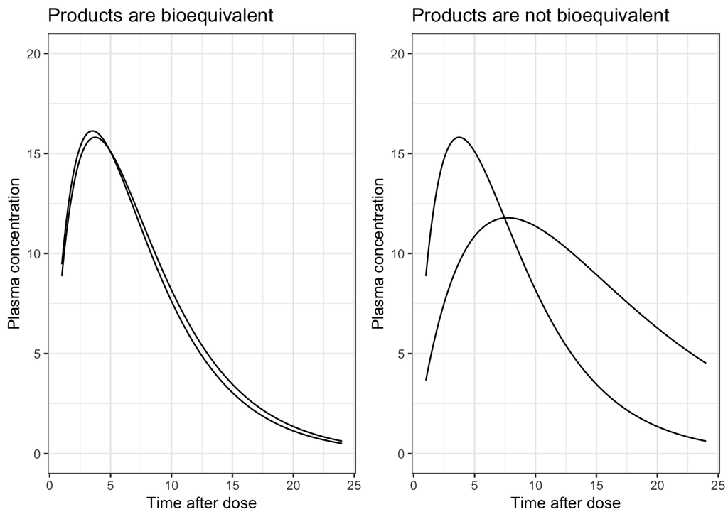

## 3.3 Data for this session

“Dataset_C.csv” contains pharmacokinetic data from a crossover study. 5 participants (a-e) were given a single oral 1000 mg dose of a reference antimicrobial drug, QMP. PK measurements were taken hourly for 24 hours following this administration. Following a washout period of 2 weeks, each participant was given a single oral 1000 mg dose of a test drug, PMP, which has been developed as a potential generic alternative to QMP.

For Part 2 of the session, we will look at these data and do some basic analysis to see whether PMP (test drug) might be bioequivalent to QMP (reference drug). We will then consider what FDA/EMA requirements for bioequivalence involve.

### 3.3.1 Task: Import and plot your data

- Import your data
- Plot your data

You can download the data for this session directly from GitHub. Copy and paste my code.

```r
dataset_c <- read.csv("https://raw.githubusercontent.com/dlonsdal/SGUL_PK_data/refs/heads/main/pk2_param_estimate/dataset_C.csv")
```

## 3.4 Estimations

### 3.4.1 Task: Subset data and estimate parameters

- Subset the data into reference and test drug datasets if you have not already done so
- Estimate Cmax and $AUC_{0-24}$ for the reference drug
- Estimate Cmax and $AUC_{0-24}$ for the test drug
- Estimate the ratio between Cmax for the test drug and the reference drug
- Estimate the ratio between AUC for the test drug and the reference drug

I will give you the answer for AUC. This is quite challenging.

```r
library(dplyr)
library(DescTools)

# 1. Calculate the individual AUC for each ID and drug
individual_AUC <- dataset_c %>%
  group_by(ID, drug) %>%
  # Calculate AUC 0-t (AUClast) using the trapezoidal rule
  summarise(AUC = AUC(x = time, y = conc, method = "trapezoid"), .groups = 'drop')
individual_AUC
```

```
## # A tibble: 10 × 3
##    ID    drug        AUC
##    <chr> <chr>     <dbl>
##  1 a     reference  305.
##  2 a     test       306.
##  3 b     reference  142.
##  4 b     test       143.
##  5 c     reference  176.
##  6 c     test       174.
##  7 d     reference  232.
##  8 d     test       232.
##  9 e     reference  127.
## 10 e     test       127.
```

```r
# 2. Calculate the individual ratios by grouping on ID and subsetting
# This step replaces pivot_wider() by pulling the two AUC values onto one row.
individual_ratios <- individual_AUC %>%
  group_by(ID) %>%
  summarise(
    # Subsetting the AUC vector where 'drug' equals 'test' or 'reference'
    AUC_Test = AUC[drug == "test"],
    AUC_Reference = AUC[drug == "reference"],
    .groups = "drop"
  ) %>%
  # Calculate the AUC ratio Test/Reference for each individual
  mutate(AUC_Ratio = AUC_Test / AUC_Reference)
individual_ratios
```

```
## # A tibble: 5 × 4
##   ID    AUC_Test AUC_Reference AUC_Ratio
##   <chr>    <dbl>         <dbl>     <dbl>
## 1 a         306.          305.     1.00
## 2 b         143.          142.     1.01
## 3 c         174.          176.     0.989
## 4 d         232.          232.     1.00
## 5 e         127.          127.     0.993
```

```r
# 3. Final summary: Calculate the Geometric Mean Ratio (GMR) and its variability
final_summary <- individual_ratios %>%
  summarise(
    # Geometric Mean Ratio (GMR): exp(mean(log(Ratio)))
    GMR_AUC = exp(mean(log(AUC_Ratio)))
  )

# Display the final summary table
final_summary
```

```
## # A tibble: 1 × 1
##   GMR_AUC
##     <dbl>
## 1   0.998
```

What do you think of these results? Do you think these drugs might be bioequivalent?

Now let’s think about what developers must do to demonstrate bioequivalence. You have touched upon this during a session in PK I.

## 3.5 Estimating $AUC_{0-t}$

With our estimations so far we have used the trapezoidal rule to calculate $AUC_{0-t}$. Do you remember what this means?

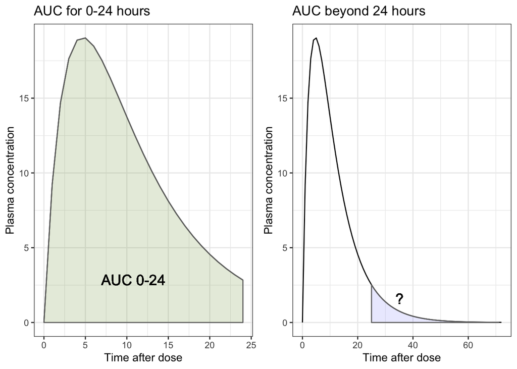

When we estimate AUC, we estimate until our last timepoint, or $AUC_{0-t}$. This is not the same as the total drug exposure.

In sessions today we have looked at $AUC_{0-24}$ and our studies have measured upto 24 hours only. In our first plot we can see $AUC_{0-24}$ shaded in green, but additional drug exposure beyond 24 hours is shaded in lilac in the second graph. To calculate total drug exposure, we must combine the measured drug exposure and account for any further exposure beyond the last measured concentration.

This is estimated as AUC 0 to infinity, or $AUC_{0-\infty}$.

This is more advanced work that will be covered during the Advanced PK module - we hope to see you then!

# 4 Advanced & further work

- Use ‘`R`’ to produce a plot of concentration-time data displaying mean and error bars (e.g. for 95% confidence interval or standard error).
- Understand the FDA and EMA requirements for proving bioequivalence above the basic calculation we have performed.
- Calculate $AUC_{0-\infty}$.
- Advanced calculations required as evidence of bioequivalence for FDA/EMA approval.